# Homework Assignment 1

Data Science and Machine Learning 2 - CEU 2018

Kristof Menyhert

2018-03-07

Load some packages:

```r
library(data.table)
library(caret)
library(rpart)
library(rpart.plot)
library(xgboost)
library(randomForest)
library(gbm)
library(ISLR)
library(skimr)
library(ROCR)
library(rpartScore)
library(plyr)
library(grid)
library(ggplot2)
library(gridExtra)
library(knitr)
```

## 1) Classification tree model (3 points)

In this problem you are going to work with the OJ dataset from the ISLR package. This dataset records purchases of two types of orange juices and presents customer and product characteristics as features. The goal is to predict which of the juices is chosen in a given purchase situation. See `?ISLR::OJ?ISLR::OJ` for a description of the variables.

Load the data:

```r
data <- data.table(OJ)
```

#### a) Create a training data of 75% and keep 25% of the data as a test set.

Modify some variables. It is not really needed for tree based models, but I converted some numeric variables to factor variables:

```r
data$StoreID <- as.factor(data$StoreID) #store ID variable
data$WeekofPurchase <- as.factor(data$WeekofPurchase) #week of purchaes
data$SpecialCH <- as.factor(data$SpecialCH)
data$SpecialMM <- as.factor(data$SpecialMM)
```

```r
training_ratio <- 0.75
set.seed(314)
train_indices <- createDataPartition(y = data$Purchase,
                                     times = 1,
                                     p = training_ratio,
                                     list = FALSE)
data_train <- data[train_indices, ]
data_test <- data[-train_indices, ]
```

#### b) Build a classification tree, determining the optimal complexity parameter via 10-fold cross validation.

- Use values for the complexity parameter ranging between 0.001 and 0.1.
- the selection criterion should be based on AUC
- Use the “one standard error” rule to select the final model

Set train control to 10 fold CV and set the oneSE rule:

```r
train_control <- trainControl(method = "cv",
                              number = 10,
                              classProbs = TRUE,
                              summaryFunction=twoClassSummary,
                              selectionFunction = "oneSE")
```

Train a simple tree model:

```r
set.seed(314)
tree_model <- train(Purchase ~ .,
                    method = "rpart",
                    data = data_train,
                    tuneGrid = data.frame("cp" = seq(0.001, 0.1, 0.001)),
                    trControl = train_control,
                    metric = "ROC")
```

Get the properties of the best model:

```r
results <- data.table(tree_model$results)



table0 <- data.table(results[cp == tree_model$bestTune$cp])

kable(table0, align = 'c', digits = 4)
```

| cp | ROC | Sens | Spec | ROCSD | SensSD | SpecSD |
| --- | --- | --- | --- | --- | --- | --- |
| 0.019 | 0.8572 | 0.8469 | 0.7639 | 0.0482 | 0.0603 | 0.0856 |

#### c) Plot the final model and interpret the result. How would you predict a new observation?

Plotting the best model:

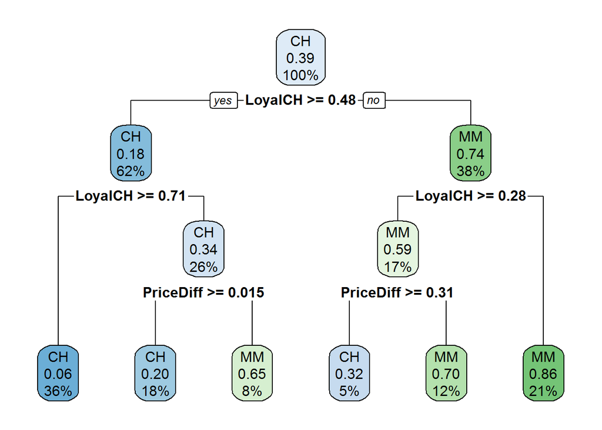

```r
rpart.plot(tree_model$finalModel)
```

Looking at the plot the first cut happens within the `LoyalCH` variable at the value of 0.48. Other cuts can be read from the plot too.

If we want to predict outcomes we should go through this plotted path above. Based on the variables of the new observations we can predict the outcome by going through a given path above. At the end of the path you will end up one of the bucket assigned with one of the predicted outcome. That will be your prediction for the new observation.

e.g.: you have an observation where the loyalCH = 0.4 then you go to the right part of the 1st cut. Then you got to left sine your variable is above 0.28. Then let’s say your PriceDif variable is 0.4. You will end up in the CH bucket. Therefore this will be your prediction.

#### d) Evaluate the final model on the test set. Is the AUC close to what we got via cross-validation?

```r
tree_prediction <- predict.train(tree_model, newdata = data_train)

confusionMatrix(data_train$Purchase, tree_prediction)
```

```
## Confusion Matrix and Statistics
##
##           Reference
## Prediction  CH  MM
##         CH 414  76
##         MM  58 255
##
##                Accuracy : 0.8331
##                  95% CI : (0.8055, 0.8583)
##     No Information Rate : 0.5878
##     P-Value [Acc > NIR] : <2e-16
##
##                   Kappa : 0.6528
##  Mcnemar's Test P-Value : 0.1419
##
##             Sensitivity : 0.8771
##             Specificity : 0.7704
##          Pos Pred Value : 0.8449
##          Neg Pred Value : 0.8147
##              Prevalence : 0.5878
##          Detection Rate : 0.5156
##    Detection Prevalence : 0.6102
##       Balanced Accuracy : 0.8238
##
##        'Positive' Class : CH
##
```

Now, draw an ROC Curve:

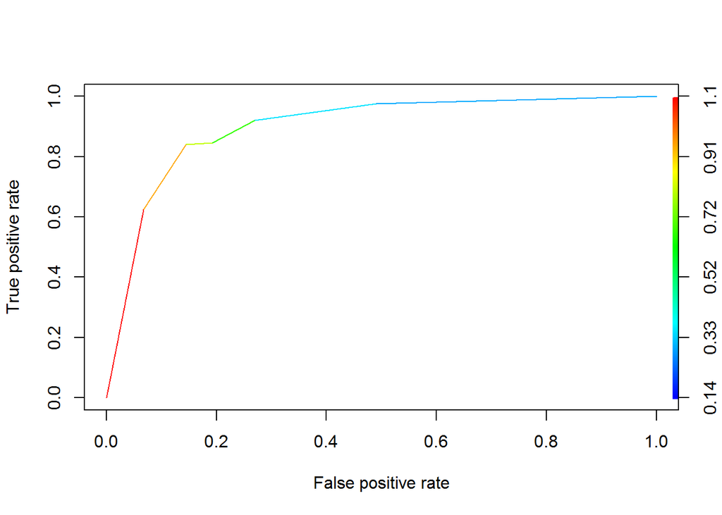

```r
test_prediction_probs <- predict.train(tree_model,
                                       newdata = data_test,
                                       type = "prob")

is_CH <- ifelse(data_test$Purchase == "CH", 1 , 0)

rocr_prediction <- prediction(test_prediction_probs$CH, is_CH)

plot(performance(rocr_prediction, "tpr", "fpr"), colorize=TRUE)
```

Finally compute the AUC of the test set:

```r
nrow(data_test)
```

```
## [1] 267
```

```r
AUC <- performance(rocr_prediction, "auc")
print(AUC@y.values[[1]])
```

```
## [1] 0.89895
```

AUC is higher in the test set than in training set. But the difference is not high. It is most likely just a coincidence based on that the test set consists only 267 observations.

## 2) Tree ensemble models (6 points)

For the same problem analyzed in Problem 1, investigate tree ensemble models:  
* random forest  
* gradient boosting machine  
* XGBoost

#### a) Try various tuning parameter combinations and select the best model using cross-validation. (This time when doing hyperparameter tuning, simply choose the best model instead of applying the oneSE rule.)

#### TRAIN 3 models:

Set trainControl once again as we do not need the oneSE rule:

```r
train_control <- trainControl(method = "cv",
                              number = 10,
                              classProbs = TRUE,
                              summaryFunction=twoClassSummary)
```

**Random Forest model:**

```r
set.seed(314)
rf_model <- train(Purchase ~ .,
                  method = "rf",
                  data = data_train,
                  trControl = train_control,
                  tuneGrid = data.frame(mtry = c(2, 3, 4, 5, 7, 9, 12, 18)), #bagging if all features are avaliable in this case 18
                  importance = T,
                  metric = "ROC")
```

**Gradient Boosting model:**

```r
gbm_grid <- expand.grid(n.trees = c(100, 300, 500, 700, 1000),
                        interaction.depth = c(2, 3, 5),
                        shrinkage = c(0.005, 0.01, 0.1, 0.3),
                        n.minobsinnode = c(5))

set.seed(314)
gbm_model <- train(Purchase ~ .,
                   method = "gbm",
                   data = data_train,
                   trControl = train_control,
                   tuneGrid = gbm_grid,
                   verbose = FALSE, # gbm by default prints too much output
                   metric = "ROC",
                   bag.fraction = 0.7)
```

**XGBoost model:**

```r
xgbGrid <- expand.grid(nrounds = c(500, 1000),
                       max_depth = c(2, 3, 5),
                       eta = c(0.01, 0.05, 0.1),
                       gamma = c(0, 0.1),
                       colsample_bytree = c(0.5, 0.7, 0.3),
                       min_child_weight = 1,
                       subsample = c(0.7))
set.seed(314)
xgboost_model <- train(Purchase ~ .,
                       method = "xgbTree",
                       data = data_train,
                       trControl = train_control,
                       tuneGrid = xgbGrid,
                       metric = "ROC")
```

#### b) Compare different models with the `resamples` function (make sure to set the same seed before model training for all 3 models). Is any of these giving significantly different predictive power than the others?

```r
resamples_object <- resamples(list("rpart" = tree_model,
                                   "rf" = rf_model,
                                   "gbm" = gbm_model,
                                   "xgboost" = xgboost_model))
summary(resamples_object)
```

```
##
## Call:
## summary.resamples(object = resamples_object)
##
## Models: rpart, rf, gbm, xgboost
## Number of resamples: 10
##
## ROC
##              Min.   1st Qu.    Median      Mean   3rd Qu.      Max. NA's
## rpart   0.8064413 0.8240593 0.8339368 0.8571799 0.8910467 0.9479921    0
## rf      0.8389668 0.8410524 0.8642199 0.8696686 0.8867908 0.9447005    0
## gbm     0.8364158 0.8805135 0.8905530 0.8975560 0.9111592 0.9776169    0
## xgboost 0.8386480 0.8775510 0.8885780 0.8957342 0.9147465 0.9749835    0
##
## Sens
##              Min.   1st Qu.    Median      Mean   3rd Qu.      Max. NA's
## rpart   0.7755102 0.7959184 0.8367347 0.8469388 0.8928571 0.9591837    0
## rf      0.7755102 0.8163265 0.8265306 0.8448980 0.8877551 0.9387755    0
## gbm     0.7551020 0.8163265 0.8673469 0.8571429 0.8979592 0.9591837    0
## xgboost 0.7551020 0.8163265 0.8469388 0.8551020 0.8928571 0.9591837    0
##
## Spec
##              Min.   1st Qu.    Median      Mean   3rd Qu.      Max. NA's
## rpart   0.6250000 0.7177419 0.7782258 0.7639113 0.8109879 0.8709677    0
## rf      0.6129032 0.6532258 0.7147177 0.7189516 0.7903226 0.8387097    0
## gbm     0.5937500 0.6774194 0.7308468 0.7320565 0.8001512 0.9032258    0
## xgboost 0.6451613 0.6696069 0.7656250 0.7510081 0.8064516 0.9032258    0
```

We also can plot this results:

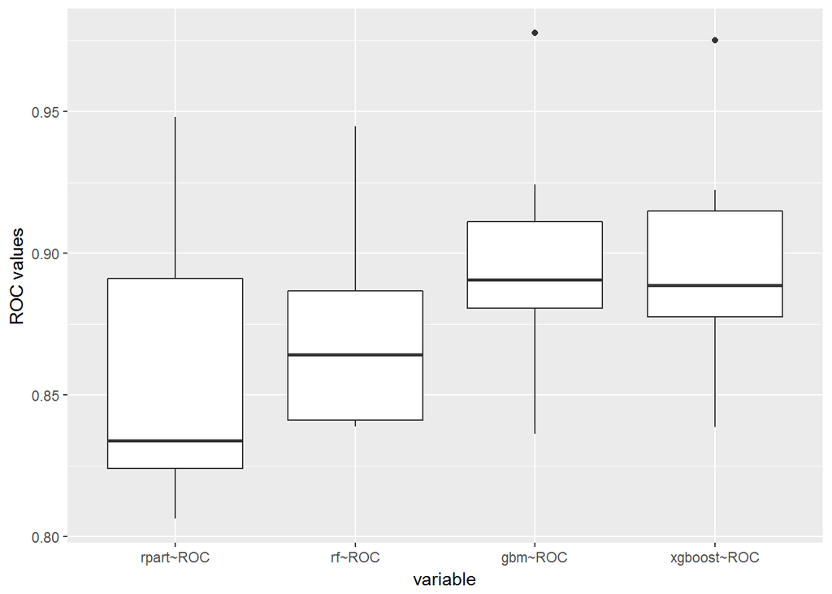

```r
table <- resamples_object$values[, c("Resample", "rpart~ROC", "rf~ROC", "gbm~ROC", "xgboost~ROC")]

#transform it to long format:
long <- melt(table, id.vars = c("Resample"))

ggplot(long, aes(x = variable, y = value)) + geom_boxplot() + labs(y = "ROC values", y = "models")
```

#### c) Choose the best model and plot ROC curve for the best model on the test set. Calculate and interpret AUC.

```r
best_model <- predict.train(xgboost_model, newdata = data_train)

confusionMatrix(data_train$Purchase, best_model)
```

```
## Confusion Matrix and Statistics
##
##           Reference
## Prediction  CH  MM
##         CH 434  56
##         MM  61 252
##
##                Accuracy : 0.8543
##                  95% CI : (0.828, 0.878)
##     No Information Rate : 0.6164
##     P-Value [Acc > NIR] : <2e-16
##
##                   Kappa : 0.6928
##  Mcnemar's Test P-Value : 0.7115
##
##             Sensitivity : 0.8768
##             Specificity : 0.8182
##          Pos Pred Value : 0.8857
##          Neg Pred Value : 0.8051
##              Prevalence : 0.6164
##          Detection Rate : 0.5405
##    Detection Prevalence : 0.6102
##       Balanced Accuracy : 0.8475
##
##        'Positive' Class : CH
##
```

Then, draw the ROC curve:

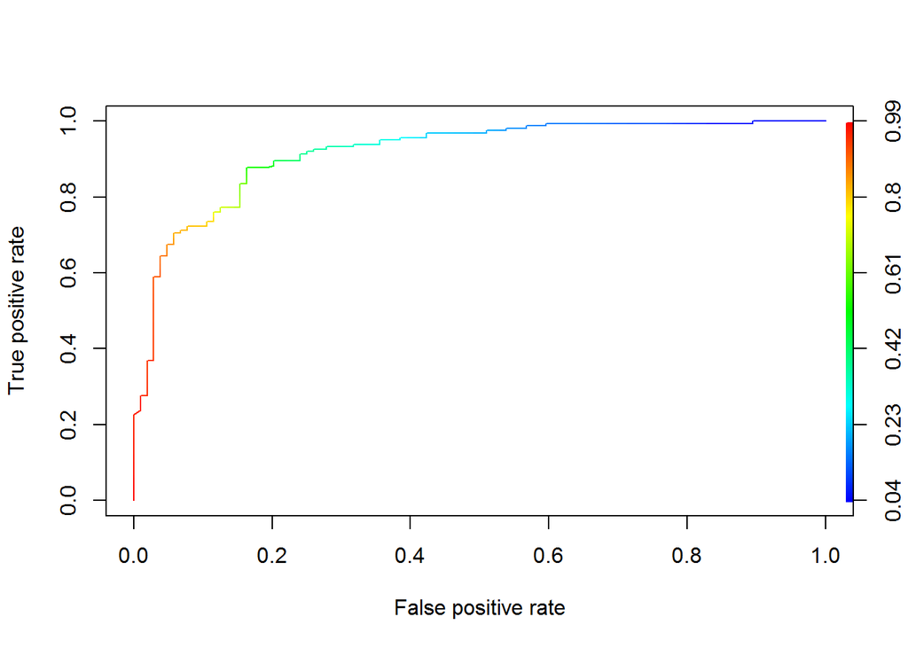

```r
best_model_probs <- predict.train(xgboost_model,
                                  newdata = data_test,
                                  type = "prob")

rocr_prediction <- prediction(best_model_probs$CH, is_CH)

plot(performance(rocr_prediction, "tpr", "fpr"), colorize=TRUE)
```

And, calculate the AUC:

```r
AUC <- performance(rocr_prediction, "auc")
print(AUC@y.values[[1]])
```

```
## [1] 0.9167355
```

#### d) Inspect variable importance plots for the 3 models. Are similar variables found to be the most important for the 3 models?

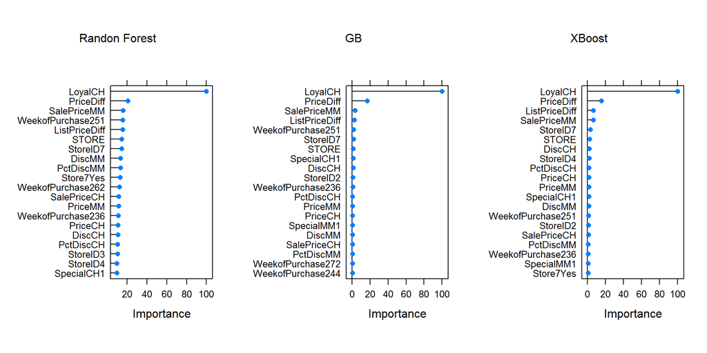

```r
grid.arrange(textGrob("Randon Forest"), textGrob("GB"), textGrob("XBoost"),
             plot(varImp(rf_model), top = 20), plot(varImp(gbm_model), top = 20), plot(varImp(xgboost_model), top = 20),
             ncol = 3,
             heights=unit(c(10,100), c("mm", "mm")))
```

Variables Importance plots are not showing the same importance, however outcomes are similar. In all three cases the most important variable is `LoyalCH` following `PriceDiff`, but we can see the for example the third most important variable is different in the case of XBoost model than the RF and the GB models.

## 3) Variable importance profiles (4 points)

Use the `Hitters` dataset and predict `log_salary` just like we did it in class.

Load the data:

```r
data <- data.table(Hitters)
data <- data[!is.na(Salary)]
data[, log_salary := log(Salary)]
data[, Salary := NULL]
```

#### a) train two random forest models: one with `mtry = 2` and another with `mtry = 10` (use the whole dataset and don’t use cross-validation). Inspect variable importance profiles. What do you see in terms of how important the first few variables are relative to each other?

```r
set.seed(314)
rf_model1 <- train(log_salary ~ .,
                  method = "rf",
                  data = data,
                  trControl = trainControl(method = "none"),
                  tuneGrid = data.frame(mtry = c(2)),
                  importance = T)

set.seed(314)
rf_model2 <- train(log_salary ~ .,
                  method = "rf",
                  data = data,
                  trControl = trainControl(method = "none"),
                  tuneGrid = data.frame(mtry = c(10)),
                  importance = T)
```

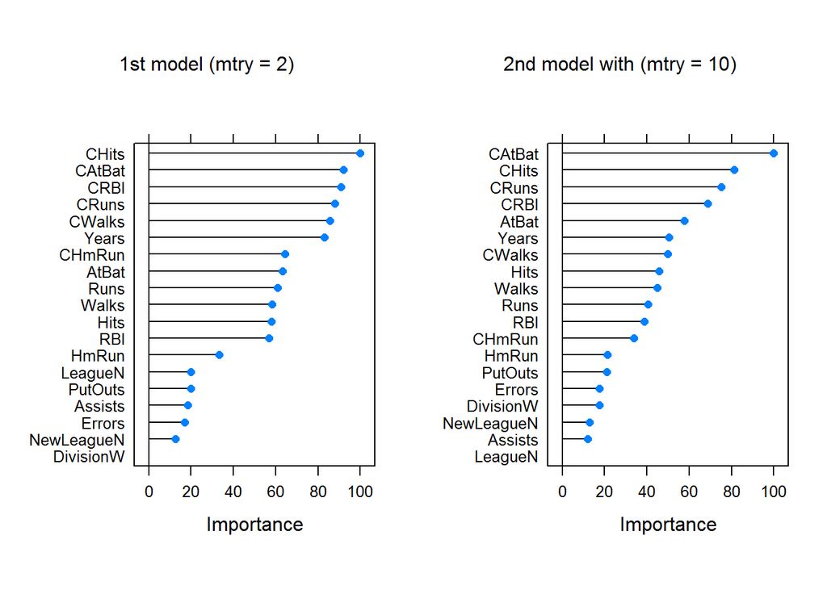

```r
grid.arrange(textGrob("1st model (mtry = 2)"), textGrob("2nd model with (mtry = 10)"),
             plot(varImp(rf_model1)), plot(varImp(rf_model2)),
             ncol = 2,
             heights=unit(c(10,100), c("mm", "mm")))
```

#### c) In the same way, estimate two `gbm` models and set `bag.fraction` to 0.1 first and to 0.9 in the second. The `tuneGrid` should consist of the same values for the two models (a dataframe with one row):

- n.trees = 500
- interaction.depth = 5
- shrinkage = 0.1
- n.minobsinnode = 5

Compare variable importance plots for the two models. What is the meaning of bag.fraction? Based on this, why is one variable importance profile more extreme than the other?

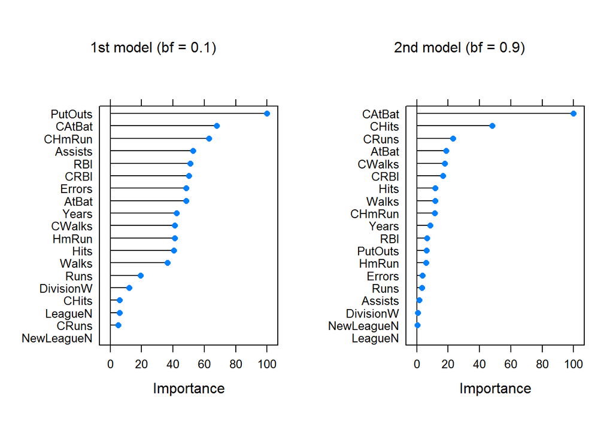

```r
gbm_grid <- expand.grid(n.trees = c(500),
                        interaction.depth = c(5),
                        shrinkage = c(0.1),
                        n.minobsinnode = c(5))

set.seed(314)
gbm_model1 <- train(log_salary ~ .,
                    method = "gbm",
                    data = data,
                    trControl = trainControl(method = "none"),
                    tuneGrid = gbm_grid,
                    verbose = FALSE,
                    bag.fraction = 0.1)

set.seed(314)
gbm_model2 <- train(log_salary ~ .,
                    method = "gbm",
                    data = data,
                    trControl = trainControl(method = "none"),
                    tuneGrid = gbm_grid,
                    verbose = FALSE,
                    bag.fraction = 0.9)

grid.arrange(textGrob("1st model (bf = 0.1)"), textGrob("2nd model (bf = 0.9)"),
             plot(varImp(gbm_model1)), plot(varImp(gbm_model2)),
             ncol = 2,
             heights=unit(c(10,100), c("mm", "mm")))
```

The fraction of the training set observations randomly selected to propose the next tree in the expansion. In this case, it adopts stochastic gradient boosting strategy.

If we set bag.fraction to 0.1 the next tree will be build on a much smaller sample then in the case of 0.9. This will result in that the model has not have time for a lots of round to train the model, and based on the small sample the chance that it will capture some noise in the data is much more likely then in the case of bag.fraction = 0.9. Based on the above mentioned information the variables importance plot will be something similar as we can see in the 1st plot if we use bag.fraction = 0.1 where the variable importance are not so diverse as in the 2nd plot where the value of bag.fraction is 0.9.